# Streaming the Future: Predicting Shows Renewals with Data

Fatiha Ashraf

2025-05-06

## Introduction

For this project, I will use the dataset “Full TMDb TV Shows Dataset 2024 (150k) by asaniczka. https://www.kaggle.com/datasets/asaniczka/full-tmdb-tv-shows-dataset-2023-150k-shows/data

This data was generated through TMDb and it recorded an extensive list out lining show’s names, season count, number of episodes, genre and more. There are 29 columns in this data set and there are 160 thousand plus rows of shows which is being updated weekly. As a marketing major, I thought it would be important to understand why a show is so popular and how I can use that information to market a show. With this, I want to ask if we can predict TV show renewals using network, ratings, and viewership metrics.

## Data Wrangling

Due to this data set being so extensive, there is a large amount of wrangling that needs to be done. To make this data set easily digestible, I started with selecting what variables, I actually needed to answer my question. Then alongside that, I filtered through to make sure that there were no empty cells. Once I did this, I noticed that in the networks column there were multiple values in one cell. To partially fix this, I separated the values so that each one would be in their own cells.

```r
tvshowdata_clean <- tvshowdata |>
  select(name, number_of_seasons, vote_count, vote_average, popularity, networks, first_air_date, last_air_date, status) |>
  filter(
    !is.na(number_of_seasons),
    !is.na(vote_count),
    !is.na(vote_average),
    !is.na(popularity),
    !is.na(networks),
    !is.na(first_air_date),
    !is.na(last_air_date),
    !is.na(status)
  ) |>
  mutate(networks = as.character(networks)) |>
  separate_rows(networks, sep = ",\\s*")
```

Once I did all of the cleaning needed here, I realized that the networks column needed to be clearer. It would be difficult to analyze my data when a show has two different networks. To fix this issue, I pivoted the data frame to be wider, so I then could have the networks put in there own separate columns. This led to the problem of shows have over 20+ networks, so what I did to combat this was to only select the columns I needed into the data set. What this did was make it easier to distinguish shows if there were put on two separate services, such as Netflix and FOX.

```r
tvshowdata_clean <- tvshowdata_clean |>
  group_by(name) |>
  mutate(network_id = row_number()) |>
  pivot_wider(
    names_from = network_id,
    values_from = networks,
    names_prefix = "network"
  ) |>
  ungroup() |>
  select(name, number_of_seasons, vote_count, vote_average, popularity, network1, first_air_date, last_air_date, status)
```

```r
selected_networks <- c("HBO", "Netflix", "AMC", "FOX", "The CW", "Disney+", "CBS", "Prime Video", "Hulu", "ABC")

tvshowdata_clean <- tvshowdata_clean |>
  filter(network1 %in% selected_networks) |>
  mutate(renewed = number_of_seasons > 1) |>
  mutate(
    first_air_date = ymd(first_air_date),
    last_air_date = ymd(last_air_date),
    show_duration = as.numeric(difftime(last_air_date, first_air_date, units = "days")),
    status = as.factor(status),
    network1 = as.factor(network1),
    renewed = as.factor(renewed)
  )
```

With this my data is finally tidy enough to use. By going through and cleaning all the data, I will have less problems now exploring the data and creating new variables!

## Data Visualization

To answer my question, I wanted to look at the renewal rate by network. From the data given, it is shown that AMC, The CW and HBO are the most likely to renew their shows. While on the other hand, Hulu, Prime Video and Disney+ had the least amount of show renewals.

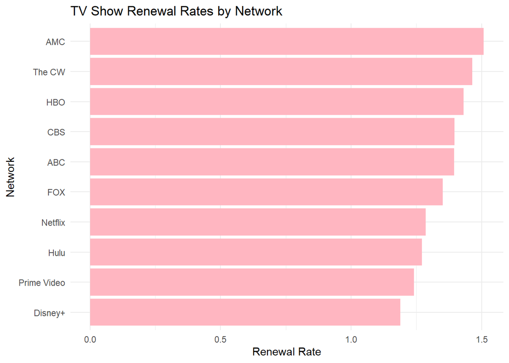

## Modeling

To understand my data, I decided to use a logistic regression model. What logistic regression does is show the possibility of something happening on a scale of one to zero. In simple terms, it can be that one is equal to “will happen” while zero is equal to “won’t happen”. In my case, we want to look at shows that are renewed vs those that aren’t, so my variables will be “renewed” and “not renewed”.

To start I split the data into training and testing sets using createDataPartition, reserving 70% of the data for training and the remaining 30% for testing. This ensures that model evaluation is performed on unseen data. The training set contained 4,232 shows, while the test set had 1,812.

```r
set.seed(34234)

train_indexes <- createDataPartition(tvshowdata_clean$renewed, p = 0.7, list = FALSE)
tv_train <- slice(tvshowdata_clean, train_indexes)
tv_test <- slice(tvshowdata_clean, -train_indexes)
```

Next, I fit the logistic regression model using network, vote average, and popularity as predictors. What the model showed was that higher voting averages and higher popularity scores were associated much more with the likely hood of renewal. Shows that aired on services such as Netflix, Hulu or Disney + were less likely to be renewed than AMC, The CW and HBO. This is something that was shown earlier when looking at the data visualization.

```r
fit <- glm(renewed ~ network1 + vote_average + popularity, data = tv_train, family = "binomial")

summary(fit)
```

```
##
## Call:
## glm(formula = renewed ~ network1 + vote_average + popularity,
##     family = "binomial", data = tv_train)
##
## Coefficients:
##                      Estimate Std. Error z value Pr(>|z|)
## (Intercept)         -1.677248   0.118619 -14.140  < 2e-16 ***
## network1AMC          0.374264   0.364137   1.028   0.3040
## network1CBS         -0.111445   0.114336  -0.975   0.3297
## network1Disney+     -1.453325   0.257907  -5.635 1.75e-08 ***
## network1FOX         -0.243371   0.136665  -1.781   0.0749 .
## network1HBO         -0.028601   0.170577  -0.168   0.8668
## network1Hulu        -0.500360   0.202638  -2.469   0.0135 *
## network1Netflix     -0.610016   0.104751  -5.824 5.76e-09 ***
## network1Prime Video -0.633886   0.139220  -4.553 5.29e-06 ***
## network1The CW       0.026413   0.256270   0.103   0.9179
## vote_average         0.151986   0.016235   9.362  < 2e-16 ***
## popularity           0.019542   0.001396  14.003  < 2e-16 ***
## ---
## Signif. codes:  0 '***' 0.001 '**' 0.01 '*' 0.05 '.' 0.1 ' ' 1
##
## (Dispersion parameter for binomial family taken to be 1)
##
##     Null deviance: 5412.5  on 4231  degrees of freedom
## Residual deviance: 4678.8  on 4220  degrees of freedom
## AIC: 4702.8
##
## Number of Fisher Scoring iterations: 7
```

The logistic regression model confirms that a show’s networks, user ratings and popularity can be useful predictors if a show will be renewed or not.

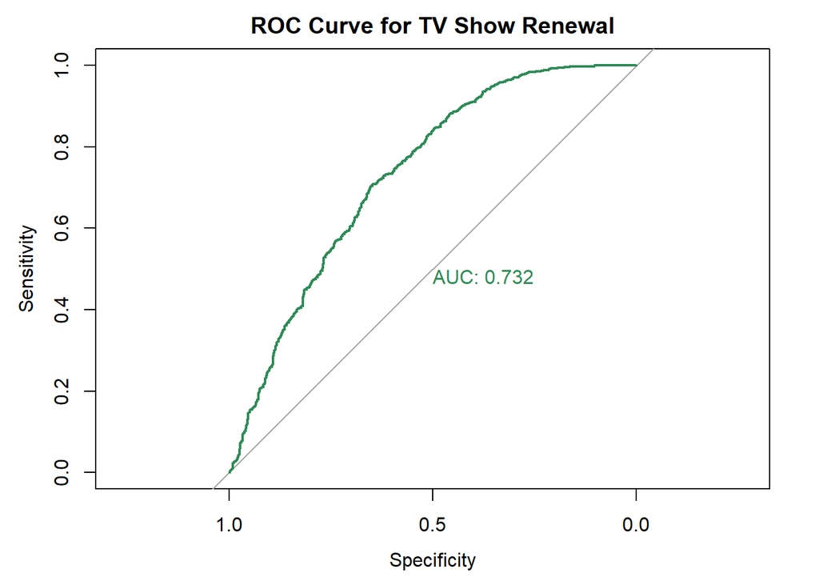

```r
plot(roc_obj, col = "seagreen", main = "ROC Curve for TV Show Renewal", print.auc = TRUE)
```

## Conclusion

This project set out to answer a central question: Can we predict TV show renewals using network, average ratings and popularity. Using data from over 5,000 TV shows and narrowing the scope to major U.S. networks, we cleaned and prepared the dataset to focus on key predictors: network, vote average, and popularity. Through data visualization, we found that networks like AMC, HBO, and The CW tend to have higher renewal rates, while services like Hulu, Disney+, and Prime Video were less consistent in renewing shows.

On the other hand, there are limitations. First, our definition of “renewed” as having more than one season may miss shows that are like mini-series or have been rebooted. Lastly, important factors such as production costs, critical reviews, or audience demographics weren’t included, which could improve the model’s precision.

Looking forward, future analysis could expand to multi-label classification for shows appearing on multiple networks or incorporate natural language processing to analyze show descriptions and reviews. With more robust data and advanced modeling techniques, we can better understand not just if a show will be renewed but why.